# R Crash Course Part 2 – *qplot()*

Rob Colautti

# 1. Getting Started

Install the `ggplot2` package

```r
library(ggplot2)
```

The *ggplot2* package includes two main functions, quickplot `qplot()` for fast graphs and the `ggplot()` function for more detailed, customizable graphs.

The package was created by the same group that also made:

*RStudio*, *RMarkdown*, *Shiny*, *ggvis*

and many other cool packages. These are available on the RStudio website:

https://www.rstudio.com/products/rpackages/

### Full ggplot2 Documentation

http://docs.ggplot2.org/current/

This tutorial focuses on *qplot()*, a quick and simple yet versatile plotting function. It is much more intuitive than R’s default graphics commands.

For more advanced graphics, see the ggplot tutorial

### General format:

`qplot(x=my.xVariable, y=my.yVariable, data=my.data.frame)`

## ppt slides

1. Graphical concepts
2. ggplot grammar
3. Explanation of selection meta-analysis data
4. anatomy of a graph

Slides

## Data setup

We will again be working with the FallopiaData.csv dataset, which can be downloaded here, and saved to your project folder to follow along.

```r
MyData<-read.csv("FallopiaData.csv",header=T)
```

# 3. Basic Graphs

## One continuous

#### Produces a histogram by default

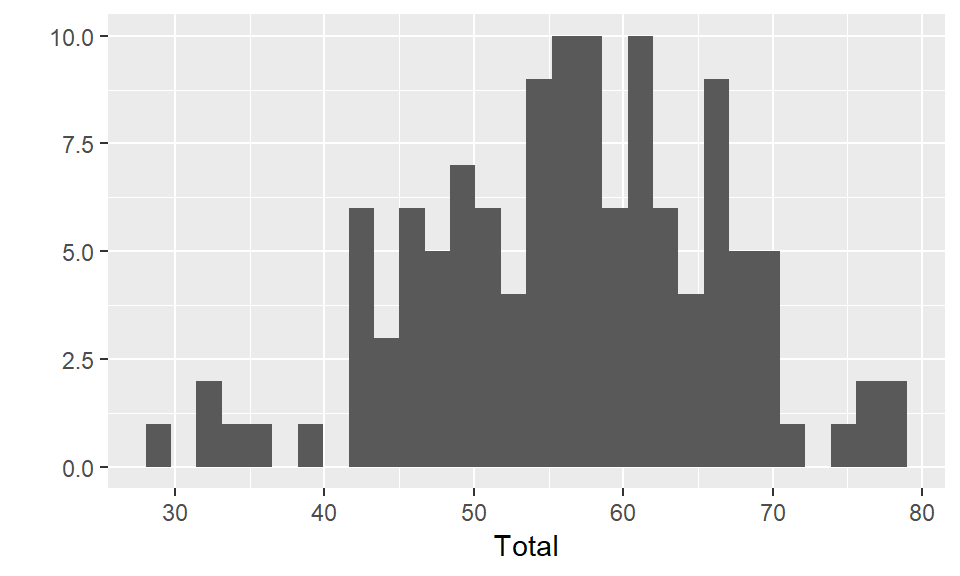

```r
qplot(x=Total,data=MyData)
```

## One categorical

#### Bar graph of counts for each category

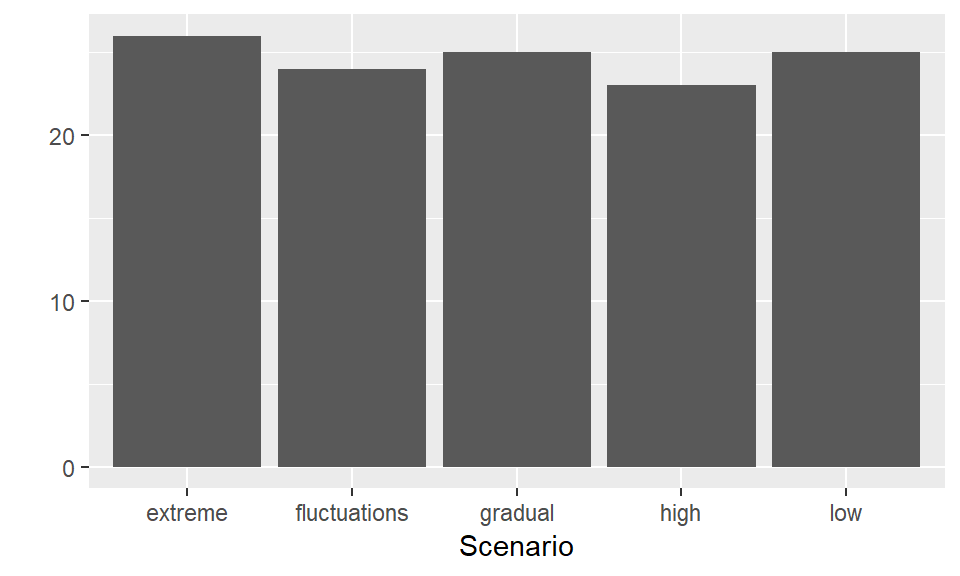

```r
qplot(x=Scenario,data=MyData)
```

## Two continuous

#### Bivariate plot

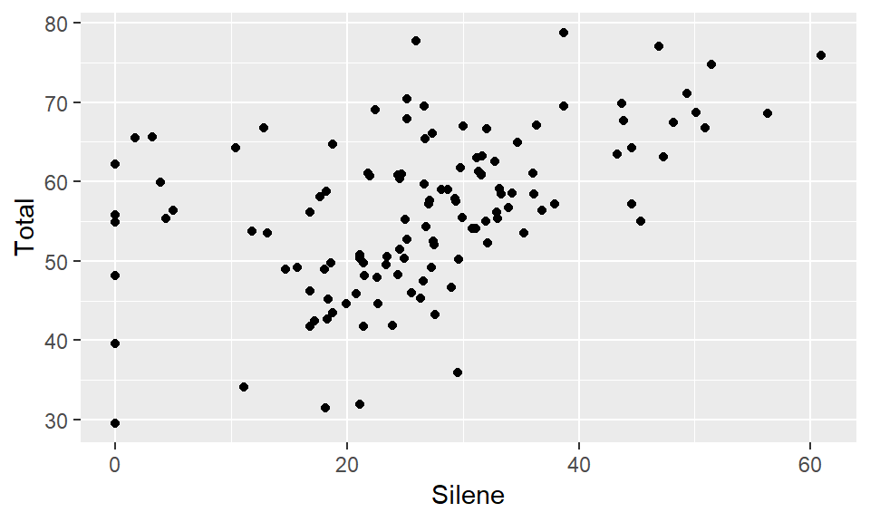

```r
qplot(x=Silene,y=Total,data=MyData)
```

## Categorical by continuous

#### Categorical scatter plot

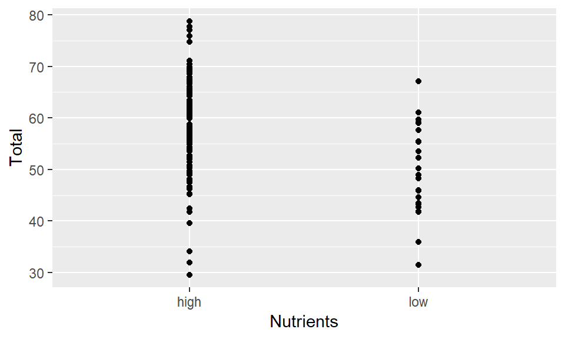

```r
qplot(x=Nutrients,y=Total,data=MyData)
```

# 4. Basic customization

### *binwidth =*

#### Change bin width of a histogram

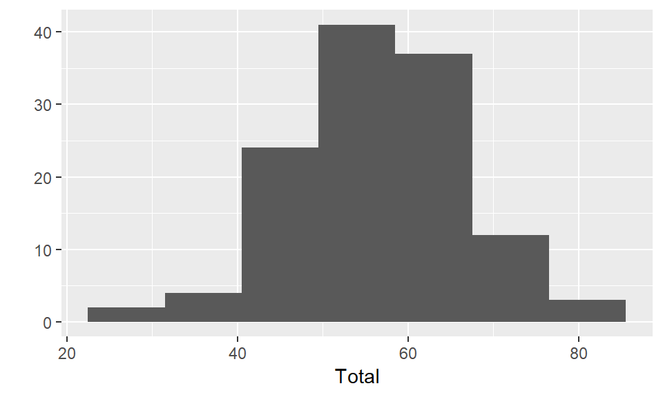

```r
qplot(x=Total,data=MyData,binwidth=9)
```

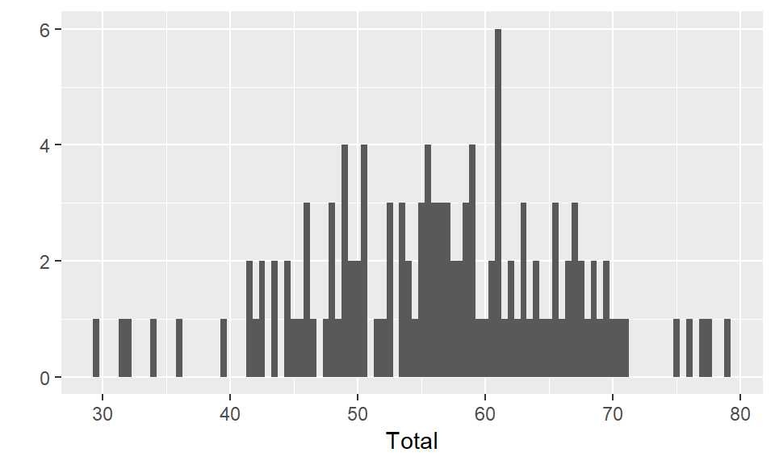

```r
qplot(x=Total,data=MyData,binwidth=0.5)
```

### *size =*

#### Controls size of points, lines, etc.

Google “pch shapes in R” http://vis.supstat.com/2013/04/plotting-symbols-and-color-palettes/

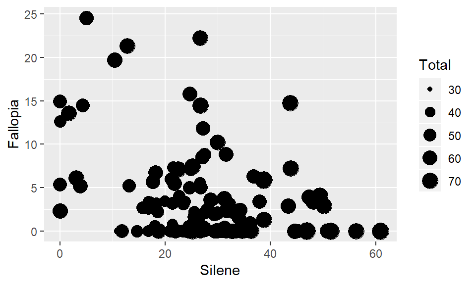

```r
qplot(x=Silene,y=Fallopia,data=MyData,size=Total) # Scale by a variable
```

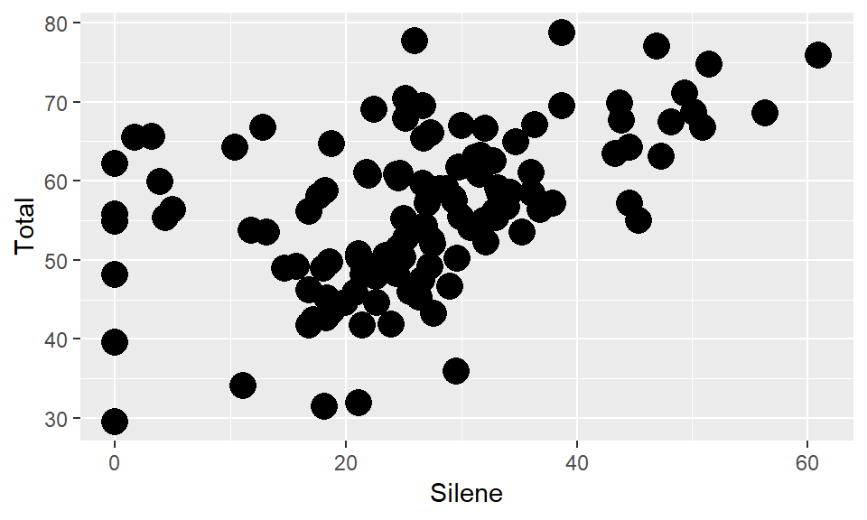

```r
qplot(x=Silene,y=Total,data=MyData,size=I(5)) # Scale by a constant
```

**NOTE:** use of identity function: *I()* for constant

Compare to:

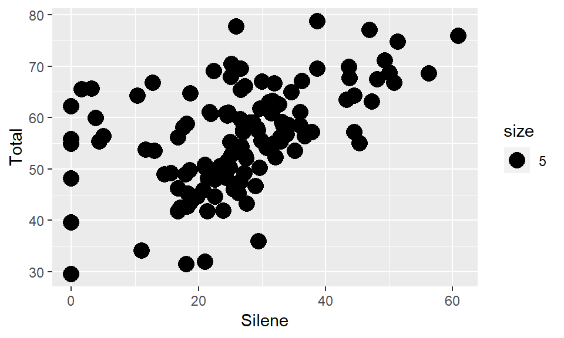

```r
qplot(x=Silene,y=Total,data=MyData,size=5)
```

Without I(), 5 is interpreted as a factor

### *colour =* or *color =*

Again, note use of *I()* for constants vs variables

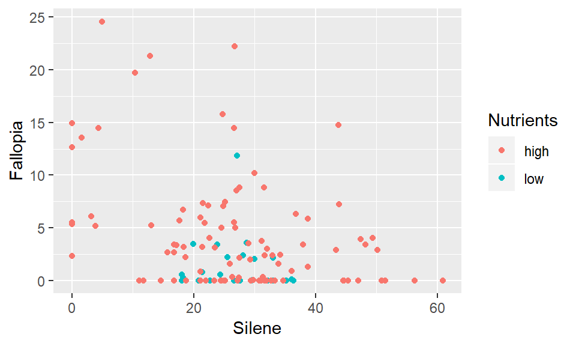

```r
qplot(x=Silene,y=Fallopia,data=MyData,colour=Nutrients) # Categorical colour
```

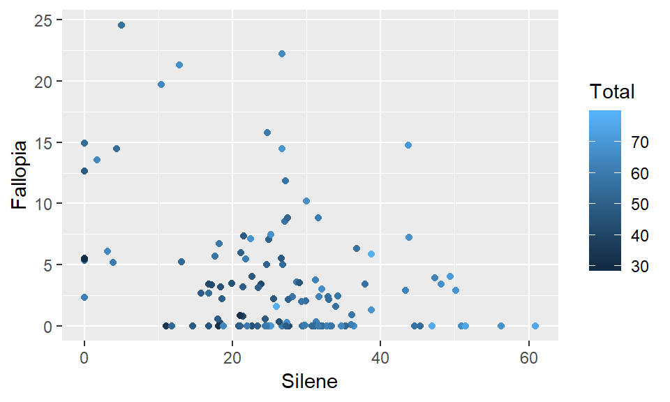

```r
qplot(x=Silene,y=Fallopia,data=MyData,colour=Total) # Continuous colour
```

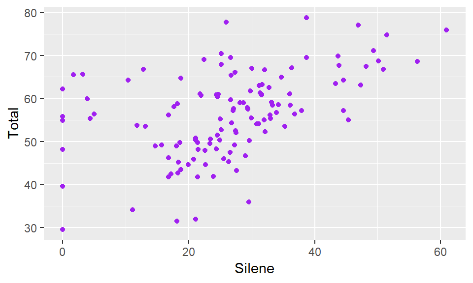

```r
qplot(x=Silene,y=Total,data=MyData,colour=I("purple")) # basic colour
```

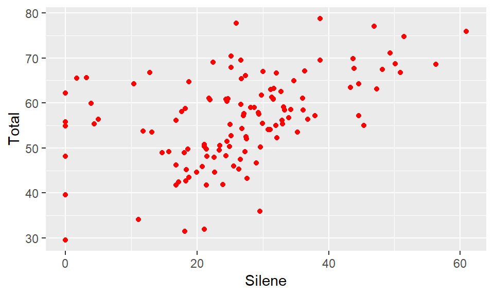

```r
qplot(x=Silene,y=Total,data=MyData,colour=I(rgb(1,0,0))) # rgb = red/green/blue
```

#### Note for histograms:

Colour applies to outlines, not so helpful

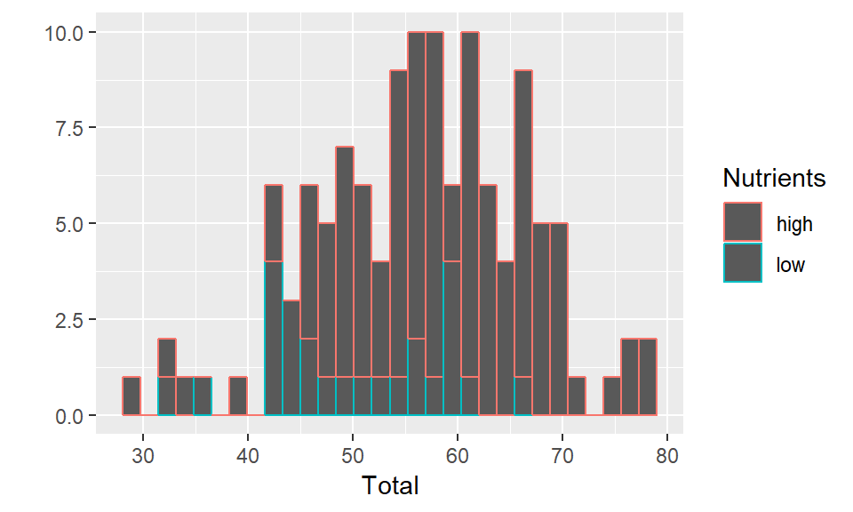

```r
qplot(x=Total,data=MyData,group=Nutrients,colour=Nutrients)
```

### *fill =*

#### More useful for histograms

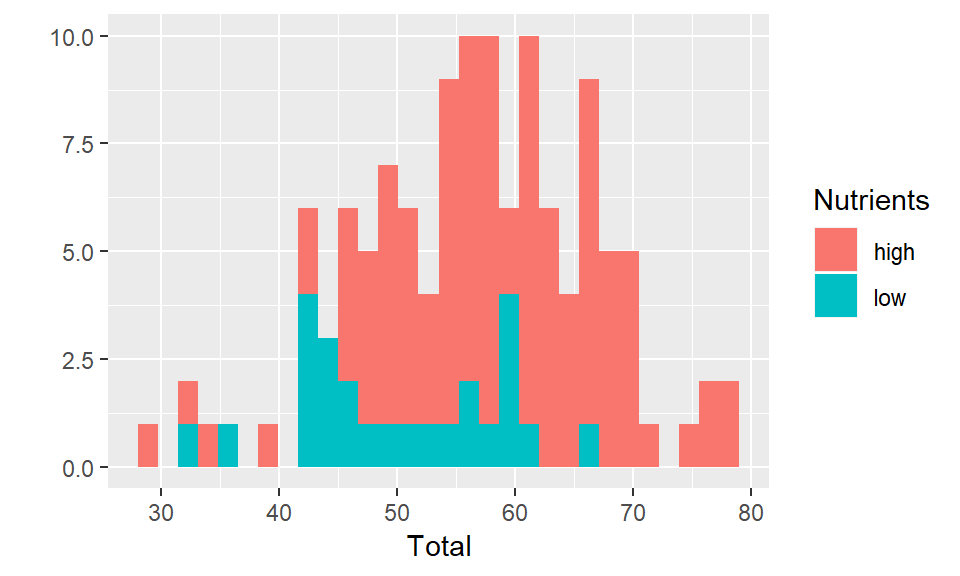

```r
qplot(x=Total,data=MyData,group=Nutrients,fill=Nutrients)
```

### *posit =*

#### Avoid stacking histogram bars

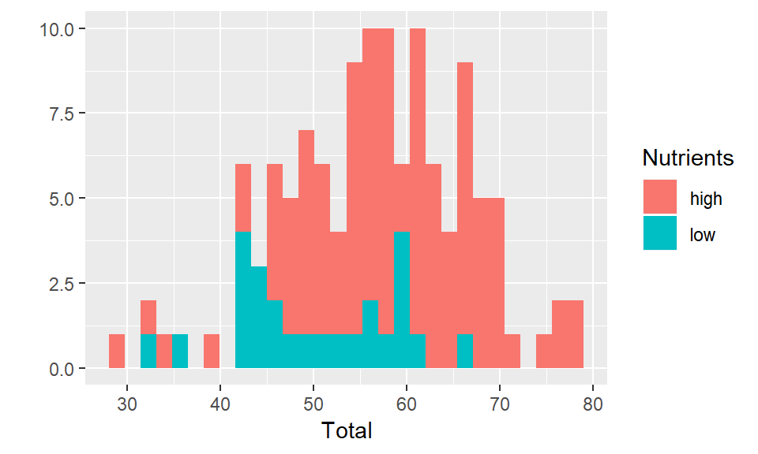

```r
qplot(x=Total,data=MyData,group=Nutrients,fill=Nutrients)
```

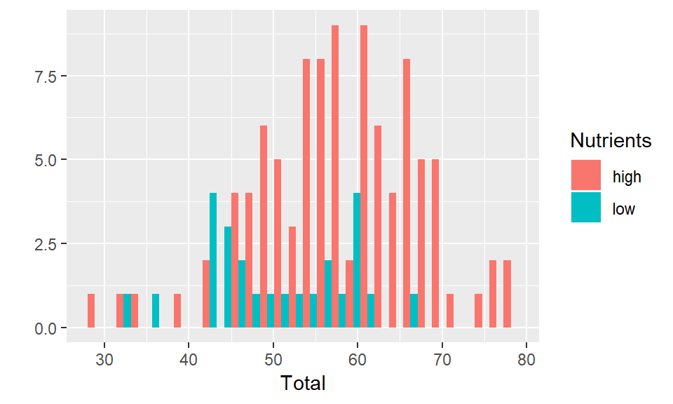

```r
qplot(x=Total,data=MyData,group=Nutrients,fill=Nutrients,posit="dodge")
```

### *alpha =*

#### Adjust transparency for overlapping points

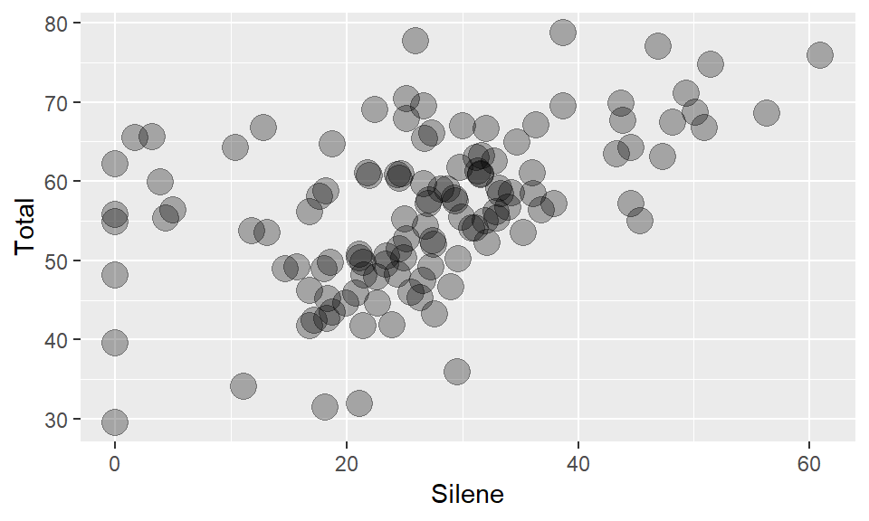

```r
qplot(x=Silene,y=Total,data=MyData,size=I(5),alpha=I(0.3))
```

### *shape =*

#### Use different shapes

Most common shape codes: 0-25

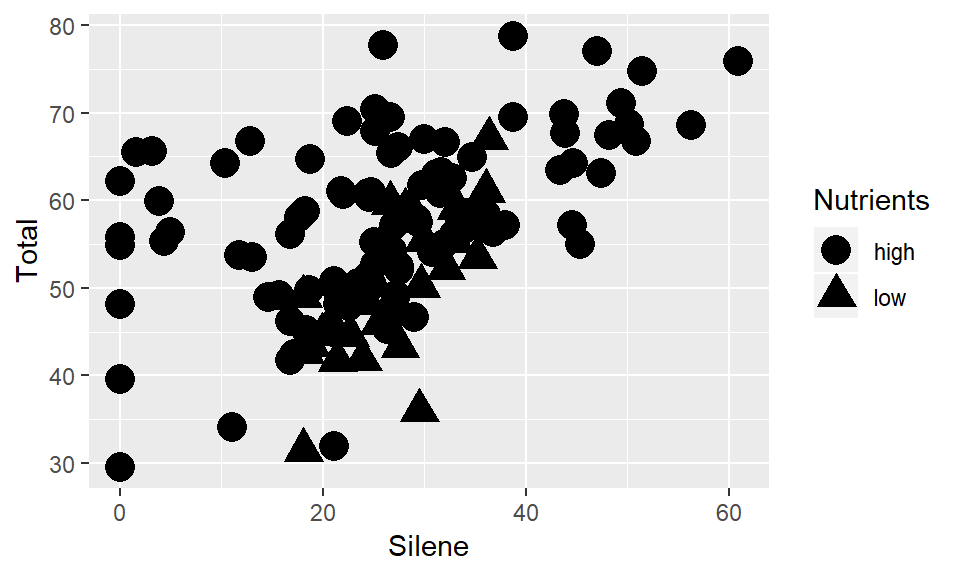

```r
qplot(x=Silene,y=Total,data=MyData,size=I(5),shape=Nutrients)
```

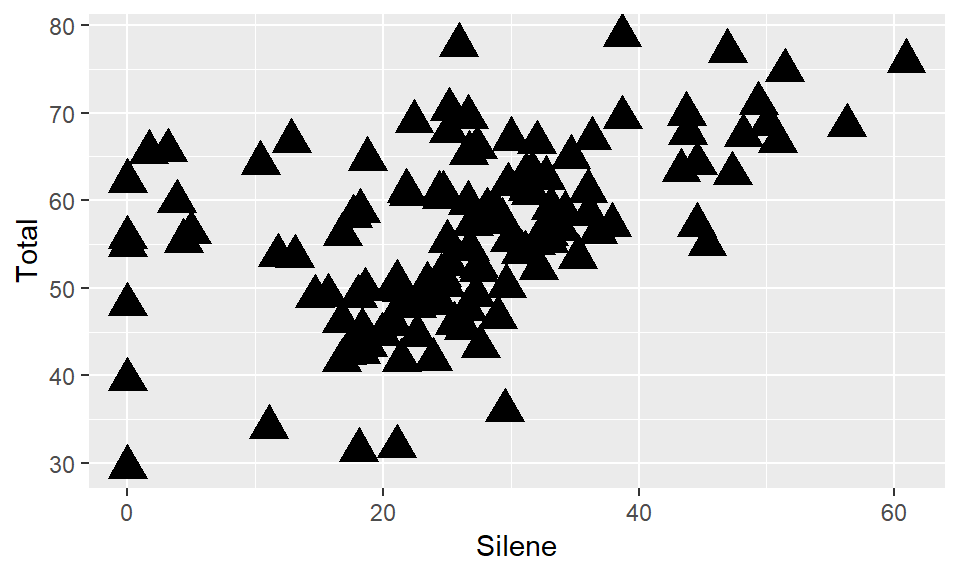

```r
qplot(x=Silene,y=Total,data=MyData,size=I(5),shape=I(17))
```

#### Some shape types have outlines

You can use *fill =* and *colour =* to customize

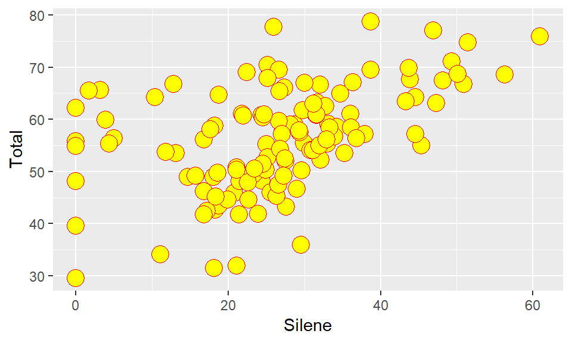

```r
qplot(x=Silene,y=Total,data=MyData,size=I(5),shape=I(21),fill=I("yellow"),colour=I("red"))
```

### *xlab =* and *ylab =*

#### Custom axis labels

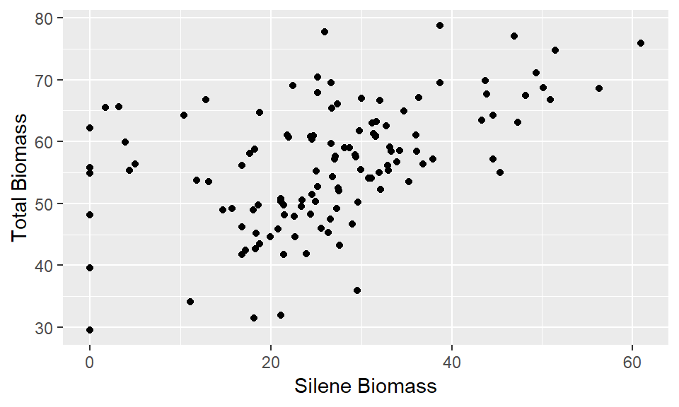

```r
qplot(x=Silene,y=Total,data=MyData,xlab="Silene Biomass",ylab="Total Biomass")
```

### *main =*

#### Add a title

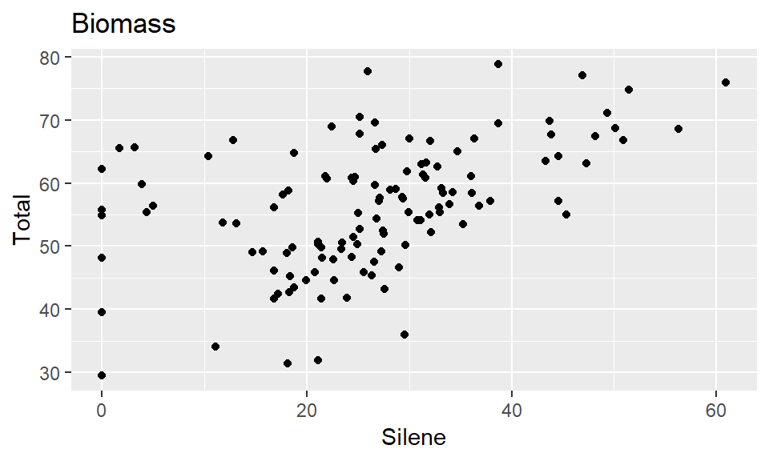

```r
qplot(x=Silene,y=Total,data=MyData,main="Biomass")
```